```python
import pandas as pd
import numpy as np
import matplotlib.pyplot as plt
from sklearn.preprocessing import OneHotEncoder, StandardScaler
from sklearn.linear_model import LogisticRegression, Ridge, Lasso, ElasticNet, LinearRegression
from sklearn.ensemble import RandomForestClassifier
from sklearn.compose import make_column_transformer
from sklearn.pipeline import make_pipeline, Pipeline
from sklearn.model_selection import train_test_split, cross_val_score, GridSearchCV, KFold, StratifiedKFold
from sklearn.svm import SVC, LinearSVC
import warnings
from sklearn.exceptions import ConvergenceWarning
warnings.simplefilter('ignore', (FutureWarning, ConvergenceWarning))
from sklearn.datasets import fetch_openml
from sklearn.utils import shuffle
from sklearn.compose import TransformedTargetRegressor
from sklearn.tree import DecisionTreeClassifier, DecisionTreeRegressor, plot_tree
from seaborn import heatmap
```

# Homework 2

## Task 1

### 1.1

```python
mnist = fetch_openml("mnist_784")
```

```python
X = mnist.data
X = X [ X.columns[X.sum() > 0]]
```

```python
X.shape
```

```
(70000, 719)
```

```python
X_train, y_train = X[:600], mnist.target[:600]
X_test, y_test = X[60000:], mnist.target[60000:]

X_trainval, y_trainval = shuffle(X_train, y_train)
```

```python
np.mean(cross_val_score(LogisticRegression(), X_trainval, y_trainval))
```

```
0.8483333333333333
```

```python
param_grid = [
{'C' : np.logspace(-3,3,7)
}
 ]
```

```python
grid = GridSearchCV(LogisticRegression(), param_grid, )
grid.fit(X_trainval, y_trainval)
```

```
GridSearchCV(estimator=LogisticRegression(),
             param_grid=[{'C': array([1.e-03, 1.e-02, 1.e-01, 1.e+00, 1.e+01, 1.e+02, 1.e+03])}])
```

```python
grid.best_params_
```

```
{'C': 100.0}
```

```python
# validation score, do not use grid.score(X_trainval, y_trainval)
grid.best_score_
```

```
0.8566666666666667
```

```python
results = pd.DataFrame(grid.cv_results_)
results.columns
```

```
Index(['mean_fit_time', 'std_fit_time', 'mean_score_time', 'std_score_time',
       'param_C', 'params', 'split0_test_score', 'split1_test_score',
       'split2_test_score', 'split3_test_score', 'split4_test_score',
       'mean_test_score', 'std_test_score', 'rank_test_score'],
      dtype='object')
```

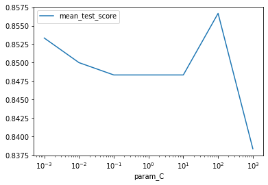

```python
results.plot('param_C', 'mean_test_score', logx = True)
```

```python
# test score
grid.score(X_test, y_test)
```

```
0.8372
```

```python
clf = grid.best_estimator_
```

```python
y_pred = clf.predict(X_test)
```

```python
misclf_proba = clf.predict_proba(X_test[y_pred != y_test])
```

```python
misclf_proba.shape
```

```
(1628, 10)
```

```python
misclf_y = np.array(y_test[y_pred != y_test]).astype(int)
```

```python
# compare probability
prob_diff = []
for i in range(misclf_proba.shape[0]):
    prob_diff_i = misclf_proba[i].max()-misclf_proba[i][misclf_y[i]]
    prob_diff.append(prob_diff_i)
```

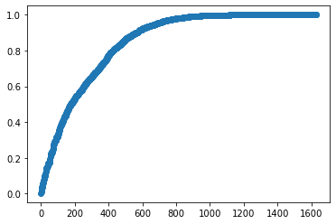

```python
plt.scatter(range(misclf_proba.shape[0]),np.sort(prob_diff))
```

```python
# compare rank
rank = []
for i in range(misclf_proba.shape[0]):
    rank_i = 10- np.where(misclf_proba[i].argsort()==misclf_y[i])[0][0]
    rank.append(rank_i)
```

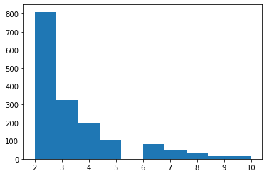

```python
plt.hist(rank)
```

Evaluate LogisticRegression using cross-validation with the default parameters. 5 points

Tune the parameters of the models using GridSearchCV. 5 points

Visualize the dependence of the validation score on the parameter C ('C' : np.logspace(-3,3,7)). 5 points

What is the performance of the best model on the test set? 5 points

(optional) For the misclassified samples in the test set, compare the probability predictions on the misclassified class and the true class. 5 points

### 1.2

```python
svc = SVC()
```

```python
np.mean(cross_val_score(svc, X_trainval, y_trainval))
```

```
0.8883333333333333
```

```python
param_grid = {'C': np.logspace(-3, 2, 6),
              'gamma': np.logspace(-3, 2, 6) / X_trainval.shape[0]}
```

```python
grid = GridSearchCV(SVC(), param_grid)
grid.fit(X_trainval, y_trainval)
```

```
GridSearchCV(estimator=SVC(),
             param_grid={'C': array([1.e-03, 1.e-02, 1.e-01, 1.e+00, 1.e+01, 1.e+02]),
                         'gamma': array([1.66666667e-06, 1.66666667e-05, 1.66666667e-04, 1.66666667e-03,
       1.66666667e-02, 1.66666667e-01])})
```

```python
grid.best_params_
```

```
{'C': 10.0, 'gamma': 1.6666666666666667e-06}
```

```python
grid.best_score_
```

```
0.5833333333333334
```

```python
grid.score(X_test, y_test)
```

```
0.4447
```

```python
results = pd.DataFrame(grid.cv_results_)
results.columns
```

```
Index(['mean_fit_time', 'std_fit_time', 'mean_score_time', 'std_score_time',
       'param_C', 'param_gamma', 'params', 'split0_test_score',
       'split1_test_score', 'split2_test_score', 'split3_test_score',
       'split4_test_score', 'mean_test_score', 'std_test_score',
       'rank_test_score'],
      dtype='object')
```

```python
plot_data = results.pivot('param_C', 'param_gamma','mean_test_score')
plot_data
```

| param_gamma param_C | 0.000002 | 0.000017 | 0.000167 | 0.001667 | 0.016667 | 0.166667 |
| --- | --- | --- | --- | --- | --- | --- |
| 0.001 | 0.131667 | 0.131667 | 0.131667 | 0.131667 | 0.131667 | 0.131667 |
| 0.010 | 0.131667 | 0.131667 | 0.131667 | 0.131667 | 0.131667 | 0.131667 |
| 0.100 | 0.131667 | 0.131667 | 0.131667 | 0.131667 | 0.131667 | 0.131667 |
| 1.000 | 0.543333 | 0.131667 | 0.131667 | 0.131667 | 0.131667 | 0.131667 |
| 10.000 | 0.583333 | 0.131667 | 0.131667 | 0.131667 | 0.131667 | 0.131667 |
| 100.000 | 0.583333 | 0.131667 | 0.131667 | 0.131667 | 0.131667 | 0.131667 |

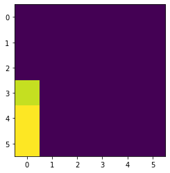

```python
plt.imshow(plot_data)
```

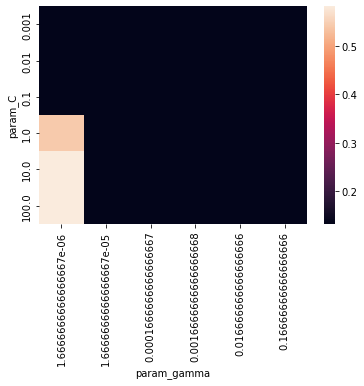

```python
heatmap(plot_data)
```

```python
clf = grid.best_estimator_
```

```python
clf.n_support_
```

```
array([58, 69, 64, 59, 59, 51, 54, 62, 49, 65])
```

```python
clf.get_params()
```

```
{'C': 10.0,
 'break_ties': False,
 'cache_size': 200,
 'class_weight': None,
 'coef0': 0.0,
 'decision_function_shape': 'ovr',
 'degree': 3,
 'gamma': 1.6666666666666667e-06,
 'kernel': 'rbf',
 'max_iter': -1,
 'probability': False,
 'random_state': None,
 'shrinking': True,
 'tol': 0.001,
 'verbose': False}
```

```python
svc.fit(X_trainval, y_trainval)
svc.n_support_
```

```
array([43, 50, 60, 53, 51, 48, 42, 50, 41, 56])
```

```python
svc.get_params()
```

```
{'C': 1.0,
 'break_ties': False,
 'cache_size': 200,
 'class_weight': None,
 'coef0': 0.0,
 'decision_function_shape': 'ovr',
 'degree': 3,
 'gamma': 'scale',
 'kernel': 'rbf',
 'max_iter': -1,
 'probability': False,
 'random_state': None,
 'shrinking': True,
 'tol': 0.001,
 'verbose': False}
```

```python
clf.n_support_ - svc.n_support_
```

```
array([15, 19,  4,  6,  8,  3, 12, 12,  8,  9])
```

```python
clf.score(X_test, y_test)
```

```
0.4447
```

SVM doesn't have probability prediction.

Evaluate SVC (default ‘rbf’ kernel) using cross-validation with the default parameters. 5 points

Tune the parameters of the models using GridSearchCV. 5 points

Visualize the dependence of the validation score on the parametes. 5 points

Compare the number of support vectors with the default parameters and the best parameters. 5 points

What is the performance of the best model on the test set? Can you get the probability prediction like logistic regression? 5 points

### 1.3

```python
np.mean(cross_val_score(RandomForestClassifier(), X_trainval, y_trainval))
```

```
0.86
```

```python
rf = RandomForestClassifier()
```

```python
rf.fit(X_trainval, y_trainval)
```

```
RandomForestClassifier()
```

```python
rf.score(X_test, y_test)
```

```
0.8511
```

RF without tuning outperformed tuned linear models.

Evaluate RandomForestClassifier using cross-validation with the default parameters. How does their performance with default parameters on the test set compare with the linear models? 10 points

## Task 2

### 2.1

```python
data = pd.read_csv('House_Rent_Dataset.csv')
```

```python
data
```

|  | Posted On | BHK | Rent | Size | Floor | Area Type | Area Locality | City | Furnishing Status | Tenant Preferred | Bathroom | Point of Contact |
| --- | --- | --- | --- | --- | --- | --- | --- | --- | --- | --- | --- | --- |
| 0 | 2022-05-18 | 2 | 10000 | 1100 | Ground out of 2 | Super Area | Bandel | Kolkata | Unfurnished | Bachelors/Family | 2 | Contact Owner |
| 1 | 2022-05-13 | 2 | 20000 | 800 | 1 out of 3 | Super Area | Phool Bagan, Kankurgachi | Kolkata | Semi-Furnished | Bachelors/Family | 1 | Contact Owner |
| 2 | 2022-05-16 | 2 | 17000 | 1000 | 1 out of 3 | Super Area | Salt Lake City Sector 2 | Kolkata | Semi-Furnished | Bachelors/Family | 1 | Contact Owner |
| 3 | 2022-07-04 | 2 | 10000 | 800 | 1 out of 2 | Super Area | Dumdum Park | Kolkata | Unfurnished | Bachelors/Family | 1 | Contact Owner |
| 4 | 2022-05-09 | 2 | 7500 | 850 | 1 out of 2 | Carpet Area | South Dum Dum | Kolkata | Unfurnished | Bachelors | 1 | Contact Owner |
| ... | ... | ... | ... | ... | ... | ... | ... | ... | ... | ... | ... | ... |
| 4741 | 2022-05-18 | 2 | 15000 | 1000 | 3 out of 5 | Carpet Area | Bandam Kommu | Hyderabad | Semi-Furnished | Bachelors/Family | 2 | Contact Owner |
| 4742 | 2022-05-15 | 3 | 29000 | 2000 | 1 out of 4 | Super Area | Manikonda, Hyderabad | Hyderabad | Semi-Furnished | Bachelors/Family | 3 | Contact Owner |
| 4743 | 2022-07-10 | 3 | 35000 | 1750 | 3 out of 5 | Carpet Area | Himayath Nagar, NH 7 | Hyderabad | Semi-Furnished | Bachelors/Family | 3 | Contact Agent |
| 4744 | 2022-07-06 | 3 | 45000 | 1500 | 23 out of 34 | Carpet Area | Gachibowli | Hyderabad | Semi-Furnished | Family | 2 | Contact Agent |
| 4745 | 2022-05-04 | 2 | 15000 | 1000 | 4 out of 5 | Carpet Area | Suchitra Circle | Hyderabad | Unfurnished | Bachelors | 2 | Contact Owner |

4746 rows × 12 columns

```python
data.columns
```

```
Index(['Posted On', 'BHK', 'Rent', 'Size', 'Floor', 'Area Type',
       'Area Locality', 'City', 'Furnishing Status', 'Tenant Preferred',
       'Bathroom', 'Point of Contact'],
      dtype='object')
```

```python
data.info()
```

```
<class 'pandas.core.frame.DataFrame'>
RangeIndex: 4746 entries, 0 to 4745
Data columns (total 12 columns):
 #   Column             Non-Null Count  Dtype
---  ------             --------------  -----
 0   Posted On          4746 non-null   object
 1   BHK                4746 non-null   int64
 2   Rent               4746 non-null   int64
 3   Size               4746 non-null   int64
 4   Floor              4746 non-null   object
 5   Area Type          4746 non-null   object
 6   Area Locality      4746 non-null   object
 7   City               4746 non-null   object
 8   Furnishing Status  4746 non-null   object
 9   Tenant Preferred   4746 non-null   object
 10  Bathroom           4746 non-null   int64
 11  Point of Contact   4746 non-null   object
dtypes: int64(4), object(8)
memory usage: 445.1+ KB
```

```python
data = data.drop(['Posted On'], axis = 1)
```

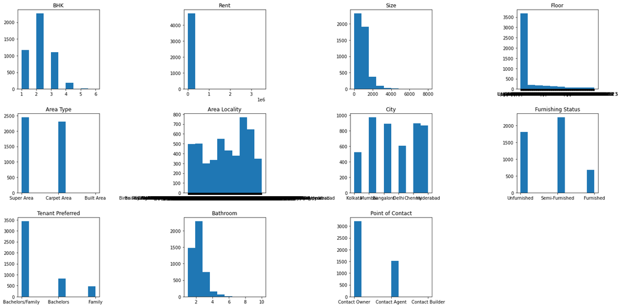

```python
plt.figure(figsize=(20, 10))
plt.subplots_adjust(hspace=0.5)
for i, feature in enumerate(data.columns):
    ax = plt.subplot(3, 4, i + 1)
    ax.hist(data[feature])
    ax.set_title(feature)
plt.tight_layout()
```

```python
# train test split
X = data.drop(['Rent'], axis=1)
target = data['Rent']
X_trainval, X_test, y_trainval, y_test = train_test_split(X, target)
categorical = X.dtypes == object
```

```python
log_regressor = TransformedTargetRegressor(
    ElasticNet(), func=np.log, inverse_func=np.exp)
```

```python
preprocess = make_column_transformer((StandardScaler(), ~categorical), (OneHotEncoder(handle_unknown='ignore'), categorical))
pipe = make_pipeline(preprocess, log_regressor)
np.mean(cross_val_score(pipe, X_trainval, y_trainval))
```

```
-0.018951940887151332
```

```python
param_grid = {
'transformedtargetregressor__regressor__alpha': np.logspace(-4, -1, 3),
'transformedtargetregressor__regressor__l1_ratio': [0.01, .1, 1]}

grid = GridSearchCV(pipe, param_grid)
grid.fit(X_trainval, y_trainval)
# test score
grid.score(X_test, y_test)
```

```
0.7128566827105305
```

```python
grid.best_params_
```

```
{'transformedtargetregressor__regressor__alpha': 0.0001,
 'transformedtargetregressor__regressor__l1_ratio': 0.1}
```

```python
# validation score
grid.best_score_
```

```
0.5782214508419912
```

```python
results = pd.DataFrame(grid.cv_results_)
results.columns
```

```
Index(['mean_fit_time', 'std_fit_time', 'mean_score_time', 'std_score_time',
       'param_transformedtargetregressor__regressor__alpha',
       'param_transformedtargetregressor__regressor__l1_ratio', 'params',
       'split0_test_score', 'split1_test_score', 'split2_test_score',
       'split3_test_score', 'split4_test_score', 'mean_test_score',
       'std_test_score', 'rank_test_score'],
      dtype='object')
```

```python
plot_data = results.pivot('param_transformedtargetregressor__regressor__alpha', 'param_transformedtargetregressor__regressor__l1_ratio','mean_test_score')
plot_data
```

| param_transformedtargetregressor__regressor__l1_ratio param_transformedtargetregressor__regressor__alpha | 0.01 | 0.10 | 1.00 |
| --- | --- | --- | --- |
| 0.000100 | 0.578083 | 0.578221 | 0.570851 |
| 0.003162 | 0.567300 | 0.561164 | 0.547932 |
| 0.100000 | 0.500503 | 0.486540 | 0.267983 |

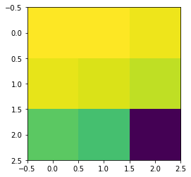

```python
plt.imshow(plot_data)
```

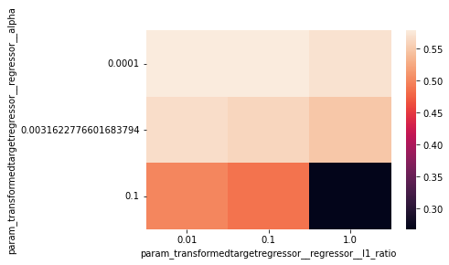

```python
heatmap(plot_data)
```

```python
grid.best_estimator_
```

```
Pipeline(steps=[('columntransformer',
                 ColumnTransformer(transformers=[('standardscaler',
                                                  StandardScaler(),
                                                  BHK                   True
Size                  True
Floor                False
Area Type            False
Area Locality        False
City                 False
Furnishing Status    False
Tenant Preferred     False
Bathroom              True
Point of Contact     False
dtype: bool),
                                                 ('onehotencoder',
                                                  OneHotEncoder(handle_unknown='ignore'),
                                                  BHK                  False
Size                 False
Floor                 True
Area Type             True
Area Locality         True
City                  True
Furnishing Status     True
Tenant Preferred      True
Bathroom             False
Point of Contact      True
dtype: bool)])),
                ('transformedtargetregressor',
                 TransformedTargetRegressor(func=<ufunc 'log'>,
                                            inverse_func=<ufunc 'exp'>,
                                            regressor=ElasticNet(alpha=0.0001,
                                                                 l1_ratio=0.1)))])
```

```python
pipe.fit(X_trainval, y_trainval)
```

```
Pipeline(steps=[('columntransformer',
                 ColumnTransformer(transformers=[('standardscaler',
                                                  StandardScaler(),
                                                  BHK                   True
Size                  True
Floor                False
Area Type            False
Area Locality        False
City                 False
Furnishing Status    False
Tenant Preferred     False
Bathroom              True
Point of Contact     False
dtype: bool),
                                                 ('onehotencoder',
                                                  OneHotEncoder(handle_unknown='ignore'),
                                                  BHK                  False
Size                 False
Floor                 True
Area Type             True
Area Locality         True
City                  True
Furnishing Status     True
Tenant Preferred      True
Bathroom             False
Point of Contact      True
dtype: bool)])),
                ('transformedtargetregressor',
                 TransformedTargetRegressor(func=<ufunc 'log'>,
                                            inverse_func=<ufunc 'exp'>,
                                            regressor=ElasticNet()))])
```

```python
default_coef = pipe.named_steps.transformedtargetregressor.regressor_.coef_
```

```python
best_coef = grid.best_estimator_.named_steps.transformedtargetregressor.regressor_.coef_
```

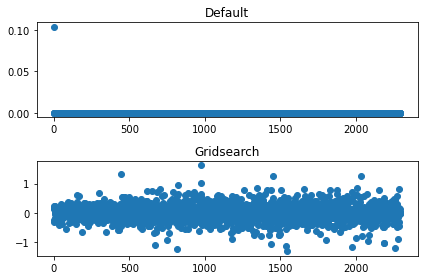

```python
fig, ax = plt.subplots(2, 1)
ax[0].set_title("Default")
ax[0].plot(default_coef, 'o')
ax[1].set_title("Gridsearch")
ax[1].plot(best_coef, 'o')

fig.tight_layout()
```

```python
# top20 from default
top20 = np.argsort(abs(default_coef))[-20:]
print(top20)
```

```
[ 752  770  768  754  755  756  757  758  759  769  760  762  763  764
  765  766  767  761 2294    2]
```

```python
# top20 from gridsearch
top20 = np.argsort(abs(best_coef))[-20:]
print(top20)
```

```
[2276 1180  751 1800  821 2078  974 2189 2188 1441  672 1536 1976 2260
  818 2033 1451 1542  446  977]
```

Visualize the univariate distribution of each continuous feature, and the distribution of the target. 5 points

Evaluate ElasticNet using cross-validation with the default parameters. 5 points

Tune the parameters of the model using GridSearchCV. 5 points

Visualize the dependence of the validation score on the parameters. 5 points

(Optional) Compare the coefficients from the best model with the ones from the default parameters? 5 points

### 2.2

```python
dt = DecisionTreeRegressor()
```

```python
preprocess = make_column_transformer((StandardScaler(), ~categorical), (OneHotEncoder(handle_unknown='ignore'), categorical))
pipe = make_pipeline(preprocess, dt)
np.mean(cross_val_score(pipe, X_trainval, y_trainval))
```

```
0.48316205371208987
```

```python
param_grid = {'decisiontreeregressor__max_depth': range(1,6)}
grid1 = GridSearchCV(pipe, param_grid)
grid1.fit(X_trainval, y_trainval)
```

```
GridSearchCV(estimator=Pipeline(steps=[('columntransformer',
                                        ColumnTransformer(transformers=[('standardscaler',
                                                                         StandardScaler(),
                                                                         BHK                   True
Size                  True
Floor                False
Area Type            False
Area Locality        False
City                 False
Furnishing Status    False
Tenant Preferred     False
Bathroom              True
Point of Contact     False
dtype: bool),
                                                                        ('onehotencoder',
                                                                         OneHotEncoder(handle_unknown='ignore'),
                                                                         BHK                  False
Size                 False
Floor                 True
Area Type             True
Area Locality         True
City                  True
Furnishing Status     True
Tenant Preferred      True
Bathroom             False
Point of Contact      True
dtype: bool)])),
                                       ('decisiontreeregressor',
                                        DecisionTreeRegressor())]),
             param_grid={'decisiontreeregressor__max_depth': range(1, 6)})
```

```python
grid1.best_params_
```

```
{'decisiontreeregressor__max_depth': 5}
```

```python
grid1.best_score_
```

```
0.5263909181594818
```

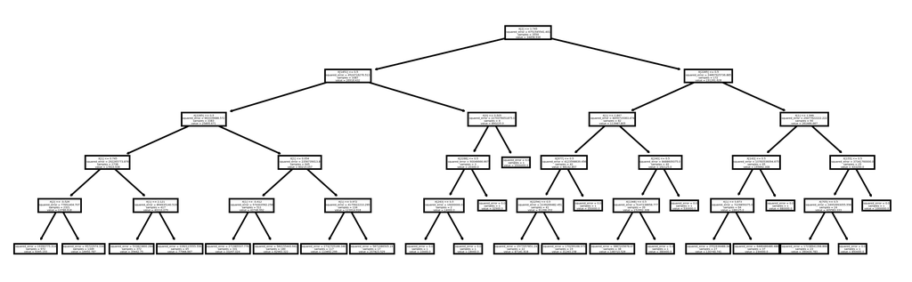

```python
tree = grid1.best_estimator_.named_steps.decisiontreeregressor
plt.figure(figsize=(10, 3), dpi=300)
tree_dot = plot_tree(tree)
```

```python
param_grid = {'decisiontreeregressor__max_leaf_nodes': range(2,20,2)}
grid2 = GridSearchCV(pipe, param_grid)
grid2.fit(X_trainval, y_trainval)
```

```
GridSearchCV(estimator=Pipeline(steps=[('columntransformer',
                                        ColumnTransformer(transformers=[('standardscaler',
                                                                         StandardScaler(),
                                                                         BHK                   True
Size                  True
Floor                False
Area Type            False
Area Locality        False
City                 False
Furnishing Status    False
Tenant Preferred     False
Bathroom              True
Point of Contact     False
dtype: bool),
                                                                        ('onehotencoder',
                                                                         OneHotEncoder(handle_unknown='ignore'),
                                                                         BHK                  False
Size                 False
Floor                 True
Area Type             True
Area Locality         True
City                  True
Furnishing Status     True
Tenant Preferred      True
Bathroom             False
Point of Contact      True
dtype: bool)])),
                                       ('decisiontreeregressor',
                                        DecisionTreeRegressor())]),
             param_grid={'decisiontreeregressor__max_leaf_nodes': range(2, 20, 2)})
```

```python
grid2.best_params_
```

```
{'decisiontreeregressor__max_leaf_nodes': 14}
```

```python
grid2.best_score_
```

```
0.4960840877395453
```

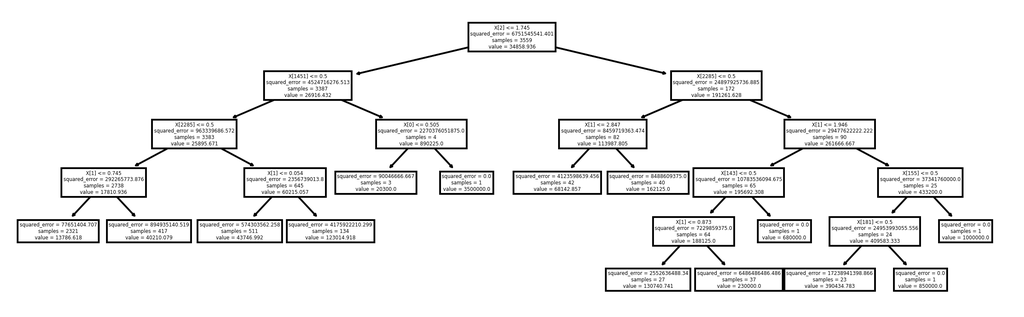

```python
tree = grid2.best_estimator_.named_steps.decisiontreeregressor
plt.figure(figsize=(10, 3), dpi=300)
tree_dot = plot_tree(tree)
```

```python
param_grid = {'decisiontreeregressor__min_samples_split': range(50,100,10)}
grid3 = GridSearchCV(pipe, param_grid)
grid3.fit(X_trainval, y_trainval)
```

```
GridSearchCV(estimator=Pipeline(steps=[('columntransformer',
                                        ColumnTransformer(transformers=[('standardscaler',
                                                                         StandardScaler(),
                                                                         BHK                   True
Size                  True
Floor                False
Area Type            False
Area Locality        False
City                 False
Furnishing Status    False
Tenant Preferred     False
Bathroom              True
Point of Contact     False
dtype: bool),
                                                                        ('onehotencoder',
                                                                         OneHotEncoder(handle_unknown='ignore'),
                                                                         BHK                  False
Size                 False
Floor                 True
Area Type             True
Area Locality         True
City                  True
Furnishing Status     True
Tenant Preferred      True
Bathroom             False
Point of Contact      True
dtype: bool)])),
                                       ('decisiontreeregressor',
                                        DecisionTreeRegressor())]),
             param_grid={'decisiontreeregressor__min_samples_split': range(50, 100, 10)})
```

```python
grid3.best_params_
```

```
{'decisiontreeregressor__min_samples_split': 50}
```

```python
grid3.best_score_
```

```
0.23219377256079793
```

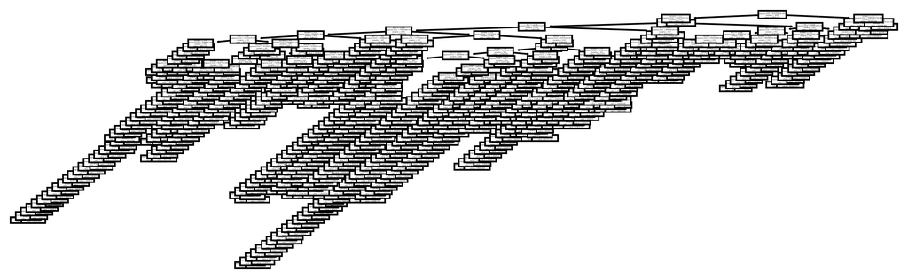

```python
tree = grid3.best_estimator_.named_steps.decisiontreeregressor
plt.figure(figsize=(10, 3), dpi=300)
tree_dot = plot_tree(tree)
```

```python
param_grid = {'decisiontreeregressor__ccp_alpha': np.linspace(0., 0.03, 4) }
grid4 = GridSearchCV(pipe, param_grid)
grid4.fit(X_trainval, y_trainval)
```

```
GridSearchCV(estimator=Pipeline(steps=[('columntransformer',
                                        ColumnTransformer(transformers=[('standardscaler',
                                                                         StandardScaler(),
                                                                         BHK                   True
Size                  True
Floor                False
Area Type            False
Area Locality        False
City                 False
Furnishing Status    False
Tenant Preferred     False
Bathroom              True
Point of Contact     False
dtype: bool),
                                                                        ('onehotencoder',
                                                                         OneHotEncoder(handle_unknown='ignore'),
                                                                         BHK                  False
Size                 False
Floor                 True
Area Type             True
Area Locality         True
City                  True
Furnishing Status     True
Tenant Preferred      True
Bathroom             False
Point of Contact      True
dtype: bool)])),
                                       ('decisiontreeregressor',
                                        DecisionTreeRegressor())]),
             param_grid={'decisiontreeregressor__ccp_alpha': array([0.  , 0.01, 0.02, 0.03])})
```

```python
grid4.best_params_
```

```
{'decisiontreeregressor__ccp_alpha': 0.02}
```

```python
grid4.best_score_
```

```
0.5023187777064722
```

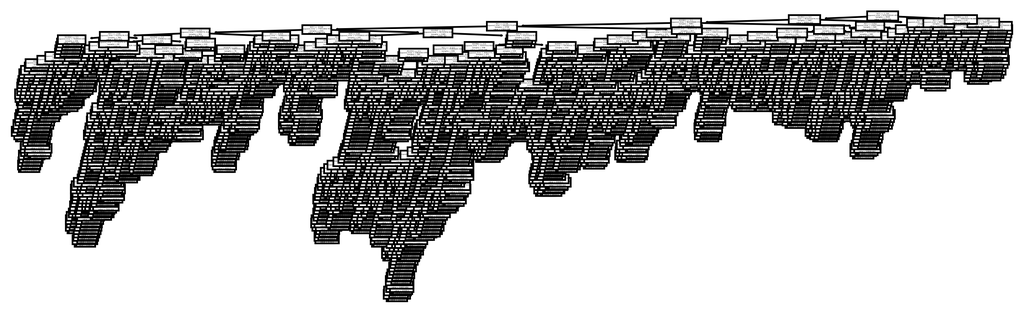

```python
tree = grid4.best_estimator_.named_steps.decisiontreeregressor
plt.figure(figsize=(10, 3), dpi=300)
tree_dot = plot_tree(tree)
```

```python
grid2.score(X_test, y_test)
```

```
0.5742321037025659
```

```python
f_imp = grid2.best_estimator_.named_steps.decisiontreeregressor.feature_importances_
```

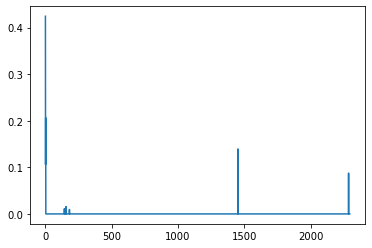

```python
plt.plot(f_imp)
```

Evaluate DecisionTreeRegressor using cross-validation with the default parameters. 5 points

Tune the parameters of the models using GridSearchCV for each of the pre-pruning parameters (max_depth, max_leaf_nodes, min_samples_split). 5 points

Compare the best cross validation score and the best tree structure from these three strategies. 5 points

Tune the parameters of the models using GridSearchCV for the post-pruning parameter (Cost Complexity Pruning). Compare the best cross validation score and the best tree structure with the pre-pruning ones. 5 points

What is the performance of the best tree model on the test set? Visualize the feature importance of the best model. 5 points